# Testing the Random Walk

Paul F. Mende

Summer 2021

*Notebooks in R Markdown*: This is an [R Markdown](http://rmarkdown.rstudio.com) Notebook. When you execute code within the notebook, the results appear beneath the code.

Try executing a code chunk by clicking the *Run* button within the chunk or by placing your cursor inside it and pressing *Ctrl+Shift+Enter*.

# Preliminaries

Before we get started, let’s install a few **packages**.

- The `install.packages` command is run **once** to download the software to your computer.
- The `library` command is run **one time per session** in order to load a packages functions and make them available.

If you have never installed them, uncomment the lines in the block below and run it one time.

```r
# install.packages("tidyverse")                # To install a single package
# install.packages("tidyquant")                # Tools for quant finance
# install.packages(c("vrtest","ggplot2"))      # Additional packages for Variance Ratios and for plotting
```

Now we’ll load packages.

```r
library(tidyquant)
library(ggplot2)
library(vrtest)
```

# Tootsie Roll

Let’s load some data and look at default summary stats for data from Tootsie Roll (TR). The file TR.csv contains daily prices, adjusted for splits and dividends, from Yahoo Finance. (Tootsie Roll actually has an unusual stock dividend history. By using the Adjusted Close data, we don’t need to worry about those details for now.)

**Technical note:** Data is often exchanged using “flat files,” which are plain text files that can be read using a simple text editor. Although they are usually structured, format details can differ; so it’s essential to pay attention to elements that might vary from one source to another such as

- Column headers (yes/no, naming conventions)
- Line breaks (CR, LF, CR/LF)
- Delimiters
- Escape characters
- Ordering
- Data types (integer/float, text/numeric)
- Date formatting (YMD, MDY, %Y/%y, etc.)
- Data errors!

Advice: don’t take anything for granted. Check your data!

```r
# Read in data file -- set your own local directory for file location

### TR <- read_csv("~/tmp/TR.csv")
```

```r
# Define query parameters
ticker <- "TR"
date_first <- "1987-12-31"
date_last  <- "2017-12-31"

#Get the data
TR <- tq_get(ticker, from=date_first, to=date_last)
```

Here is what the price looks like over time

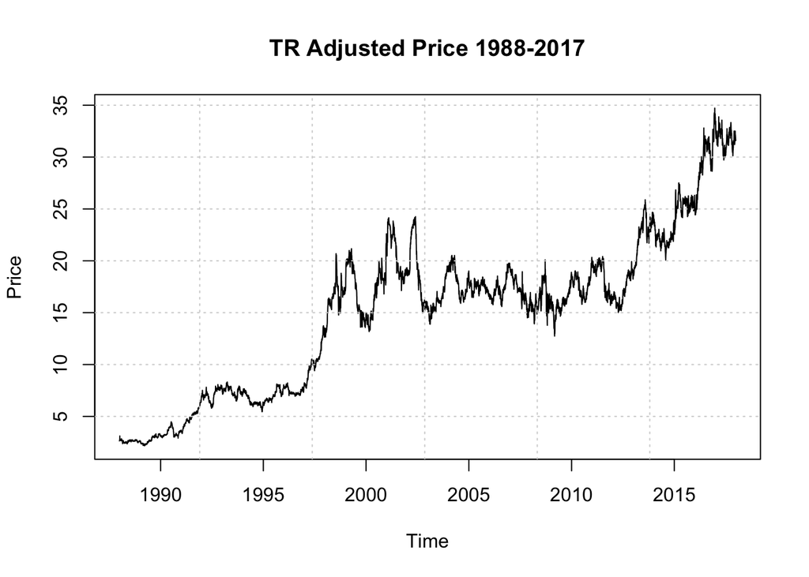

```r
plot(TR$date,TR$adjusted,type="l",xlab="Time",ylab="Price",main="TR Adjusted Price 1988-2017");grid()
```

Now we extract the time series of prices and compute the series of 1-day returns,
$$r_t = \log(P_t/P_{t-1}) =
\log(P_t/P_0) - \log(P_{t-1}/P_0)$$
.

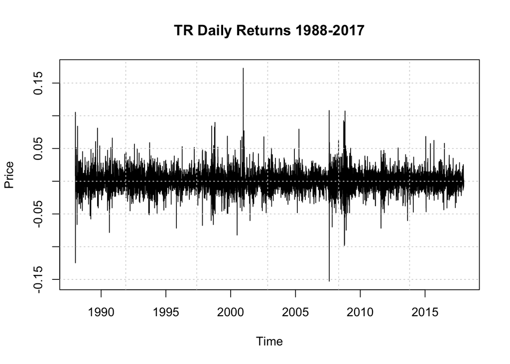

```r
# Compute the returns.  Remember that the first return is recorded on the second trade date. That's why we retrieve prices before the first trade date of interest.

P    <- TR$adjusted
r    <- diff(log(P))
N    <- length(r)

# The returns can also be stored as a new column in TR.
# NA: one less return than we do prices. So if we want things to line up, the return corresponding to our very first price is not available because we don't know the price before that.
TR$r <- c(NA, diff(log(TR$adjusted)))

# Trim off the first row, which has return NA
TR   <- TR[-1,]



plot(TR$date,TR$r,type="l",xlab="Time",ylab="Price",main="TR Daily Returns 1988-2017");grid()
```

The daily return series is noisy, and the mean value is barely visible. However the scale of the noise fluctuations is not constant over time. This is the phenomenon of time-varying volatility. Compare the graph above with the simulation below, in which simulated returns have the same average volatility and zero mean.

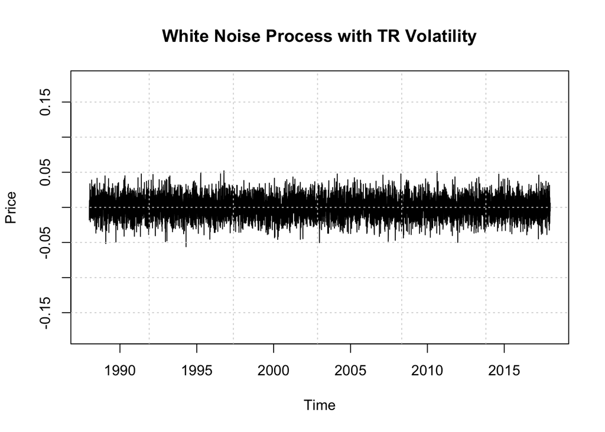

```r
plot(TR$date,rnorm(nrow(TR))*sd(TR$r),type="l",ylim=c(-0.18,0.18),xlab="Time",ylab="Price",main="White Noise Process with TR Volatility");grid()
```

## Summary statistics and return distribution

These are high-level summary stats that R provides for any data frame.

```r
summary(TR)
```

```
    symbol               date                 open             high
 Length:7561        Min.   :1988-01-04   Min.   : 3.393   Min.   : 3.427
 Class :character   1st Qu.:1995-06-23   1st Qu.:10.079   1st Qu.:10.197
 Mode  :character   Median :2002-12-24   Median :20.012   Median :20.210
                    Mean   :2002-12-26   Mean   :18.171   Mean   :18.344
                    3rd Qu.:2010-06-29   3rd Qu.:23.374   3rd Qu.:23.617
                    Max.   :2017-12-29   Max.   :36.606   Max.   :37.005
      low            close           volume           adjusted
 Min.   : 3.36   Min.   : 3.36   Min.   :      0   Min.   : 2.167
 1st Qu.:10.01   1st Qu.:10.08   1st Qu.:  40926   1st Qu.: 7.461
 Median :19.76   Median :20.00   Median :  77852   Median :16.403
 Mean   :17.99   Mean   :18.17   Mean   : 103065   Mean   :15.077
 3rd Qu.:23.18   3rd Qu.:23.41   3rd Qu.: 129467   3rd Qu.:19.112
 Max.   :36.21   Max.   :36.92   Max.   :6550235   Max.   :34.720
       r
 Min.   :-0.1527465
 1st Qu.:-0.0077943
 Median : 0.0000000
 Mean   : 0.0003284
 3rd Qu.: 0.0080969
 Max.   : 0.1726331
```

# Annualization conventions

We typically report return and risk measures in annualized terms. By convention, we assume a typical year has 252 trading days and use the following rules:

- Annualized return = 252 * (Daily return)
- Annualized std. dev. = sqrt(252) * (Daily std. dev)

For monthly returns, replace the 252 by 12.

```r
mean(r)*252     # Mean return for TR (annualize by 252 days/year)
```

```
[1] 0.08276919
```

```r
sd(r)*sqrt(252) # Volatility of TR (annualize with square root!)
```

```
[1] 0.2422571
```

```r
summary(r)
```

```
      Min.    1st Qu.     Median       Mean    3rd Qu.       Max.
-0.1527465 -0.0077943  0.0000000  0.0003284  0.0080969  0.1726331
```

The histogram of returns has fat tails (and therefore a thin middle). Because it is the unconditional distribution of returns, independent of their time ordering, it tells nothing about the causal structure of return correlations.

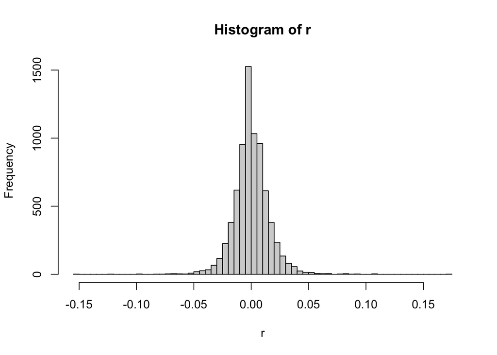

```r
hist(r, breaks=50)
```

# Lo & MacKinlay

Following Lo & MacKinlay, we ask whether the measured sample variance of returns grows linearly as function of the observation interval.

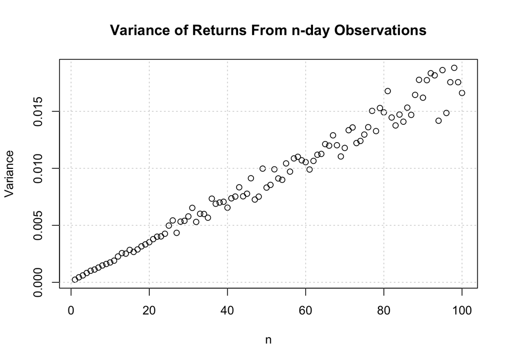

```r
Variance <- var(diff(log(P)))

for (n in 2:100) {
  Variance[n] <- var(diff(log(P[seq(from=n, to=length(P), by=n)])))
}

plot(Variance,xlab="n",main="Variance of Returns From n-day Observations");grid()
```

Looks linear, doesn’t it? Is that good enough? What about the slope? What about the raggedness on the right side of the graph? Is that simply noise due to have a smaller number of samples when the window size gets large? Or could there be a systematic deviation of the linear rule hiding in the graph?

# Variance and Ratios

Here we define functions for $\widehat \sigma^2_c$, which is a function of a series of observations $X_t$ and an aggregation length $q$.

The $z$-statistics and $p$-values follow from the distribution of the estimator as a random variable

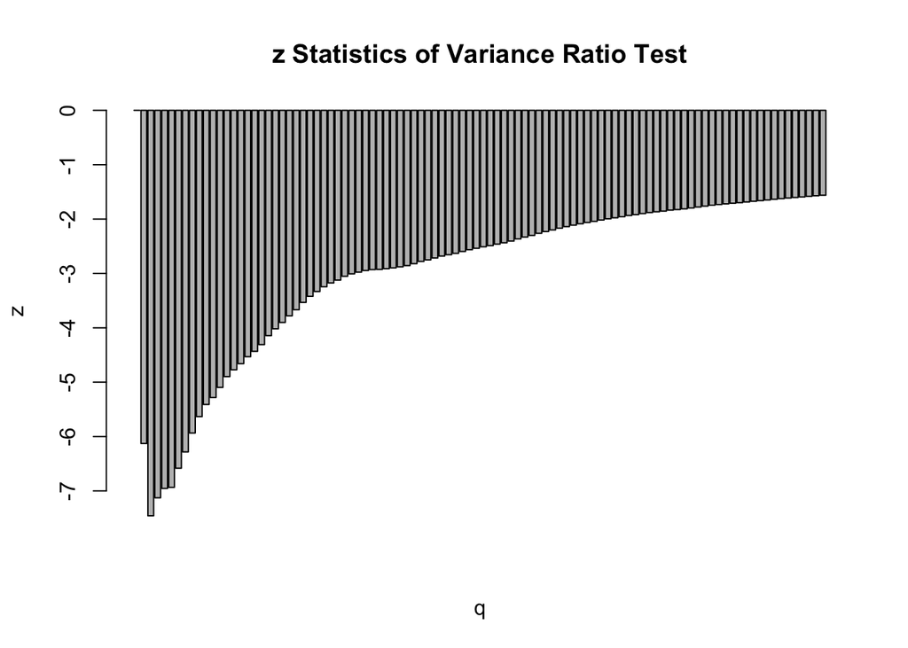

```r
variance.c <- function(X, q) {
# Compute variance statistic from overlapping q-period windows
# See Lo & MacKinlay (1988), p. 47, Eq. 12

  T     <- length(X) - 1
  mu    <- (X[T+1] - X[1])/T
  m     <- (T-q)*(T-q+1)*q/T
  sumsq <- 0
  for (t in q:T) {
    sumsq <- sumsq + (X[t+1] - X[t-q+1] - q*mu)^2
  }
  return(sumsq/m)
}

z <- function(X, q) {
# Compute sampling statistic for variance ratio
# See Lo & MacKinlay (1988), p. 47, last line (after Eqs. 12-14)
  T <- length(X) - 1
  c <- sqrt(T*(3*q)/(2*(2*q-1)*(q-1)))
  M <- variance.c(X,q)/variance.c(X,1) - 1
  z <- c*M
  return(z)
}

Vc      <- 0; for (q in 1:100) {Vc[q] <- variance.c(log(P),q)}
zstats  <- 0; for (q in 2:100) {zstats[q] <- z(log(P),q) }
pValues <- 2*pnorm(-abs(zstats))
barplot(zstats, ylab="z",xlab="q",main="z Statistics of Variance Ratio Test")
```

## Interpreting the test statistics

get a rough idea without the precise statistical analysis

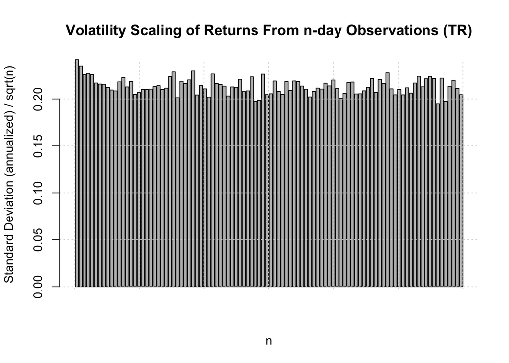

```r
sigma <- sqrt(252)*sd(diff(log(P)))

for (n in 2:100) {
  sigma[n] <- sqrt(252/n)*sd(diff(log(P[seq(from=n, to=length(P), by=n)])))
}

barplot(sigma,xlab="n",ylab="Standard Deviation (annualized) / sqrt(n)",main="Volatility Scaling of Returns From n-day Observations (TR)");grid()
```

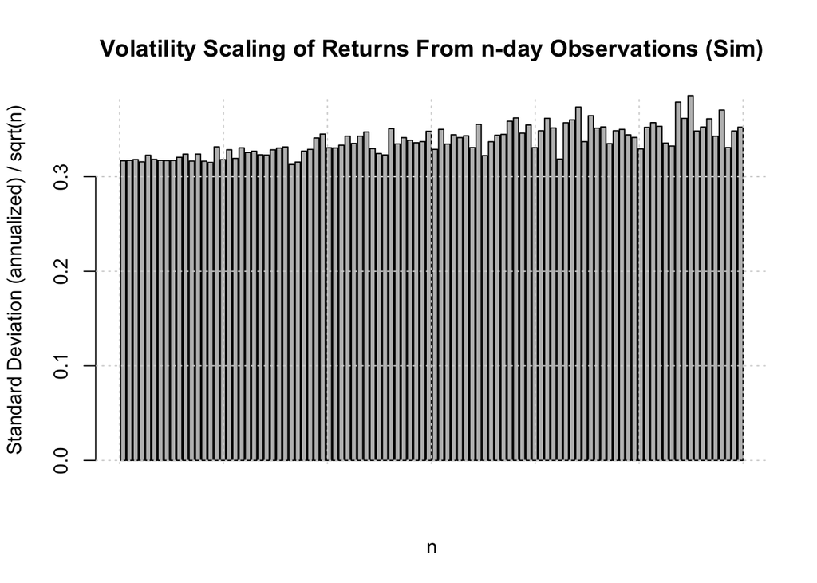

```r
P.MC <- exp(cumsum(rnorm(N)*0.02)) # Monte Carlo returns 32% vol
sigma.MC <- sqrt(252)*sd(diff(log(P.MC)))

for (n in 2:100) {
  sigma.MC[n] <- sqrt(252/n)*sd(diff(log(P.MC[seq(from=n, to=N, by=n)])))
}

barplot(sigma.MC,xlab="n",ylab="Standard Deviation (annualized) / sqrt(n)",main="Volatility Scaling of Returns From n-day Observations (Sim)");grid()
```